# MA678 Homework 2

9/20/2022

## 11.5

*Residuals and predictions*: The folder `Pyth` contains outcome $y$ and predictors $x_1$, $x_2$ for 40 data points, with a further 20 points with the predictors but no observed outcome. Save the file to your working directory, then read it into R using `read.table()`.

### (a)

Use R to fit a linear regression model predicting $y$ from $x_1$, $x_2$, using the first 40 data points in the file. Summarize the inferences and check the fit of your model.

```r
df <- read.table("pyth.txt",header=TRUE)
head(df)
```

```
##       y   x1    x2
## 1 15.68 6.87 14.09
## 2  6.18 4.40  4.35
## 3 18.10 0.43 18.09
## 4  9.07 2.73  8.65
## 5 17.97 3.25 17.68
## 6 10.04 5.30  8.53
```

```r
data_points <- df[1:40, ]
no_data_points <-df[41:60,]
fit<- lm(y ~ x1+x2,data= data_points)
summary(fit)
```

```
##
## Call:
## lm(formula = y ~ x1 + x2, data = data_points)
##
## Residuals:
##     Min      1Q  Median      3Q     Max
## -0.9585 -0.5865 -0.3356  0.3973  2.8548
##
## Coefficients:
##             Estimate Std. Error t value Pr(>|t|)
## (Intercept)  1.31513    0.38769   3.392  0.00166 **
## x1           0.51481    0.04590  11.216 1.84e-13 ***
## x2           0.80692    0.02434  33.148  < 2e-16 ***
## ---
## Signif. codes:  0 '***' 0.001 '**' 0.01 '*' 0.05 '.' 0.1 ' ' 1
##
## Residual standard error: 0.9 on 37 degrees of freedom
## Multiple R-squared:  0.9724, Adjusted R-squared:  0.9709
## F-statistic: 652.4 on 2 and 37 DF,  p-value: < 2.2e-16
```

```r
# the result shows that p value for intercept, coefficient of x1 and x2 are all very small, they are working well
```

### (b)

Display the estimated model graphically as in Figure 10.2

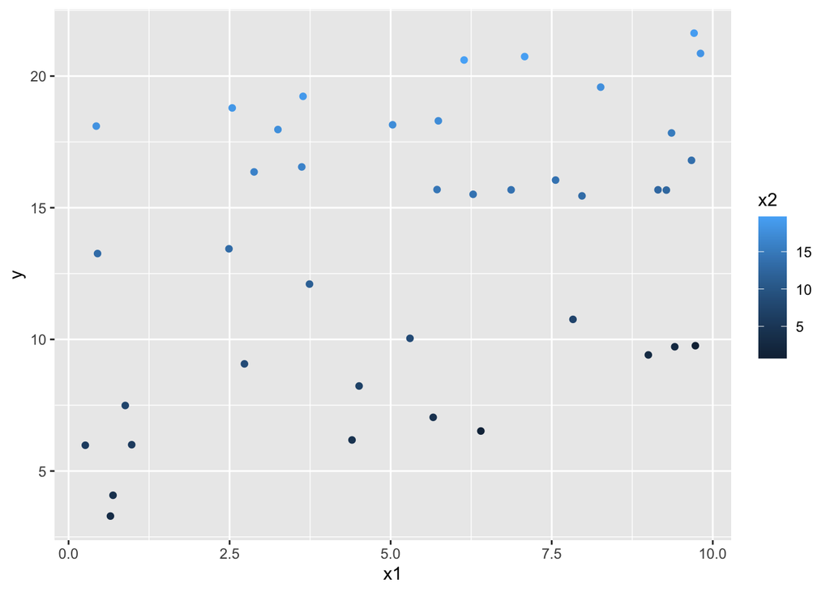

```r
library(ggplot2)
ggplot(data_points,aes(x=x1,y=y,color=x2))+
  geom_point()+
  geom_smooth(method="lm",formula= y~x1+x2,se=FALSE)
```